← Voltar ao Portal

[figure not shown]

Programa 438

# Síntese Avaliativa do Desempenho dos Programas do PPA Bahia 2024–2027

# **1 - Desempenho Global do Programa**

Este documento apresenta uma Síntese Avaliativa do Desempenho do Programa do Plano Plurianual - PPA 2024- 2027, trazendo uma visão estratégica dos seus resultados, de forma sintética, transparente e colaborativa. Serão levados em consideração o Indicador Sintético de Desempenho do Programa (ISDP), a evolução dos Indicadores de Programa, a eficácia das metas dos Indicadores de Compromisso, o desempenho da execução orçamentária-financeira e da execução física das Ações orçamentárias. O ISDP é uma síntese dessas quatro dimensões, destacando o desempenho do programa em relação aos resultados obtidos e aos esforços despendidos.  
Adicionalmente, são apresentados os principais resultados alcançados, evidenciando os avanços e conformidades dos cinco programas com melhores resultados, além das oportunidades de melhoria dos cinco, com menores resultados. Enquanto neste documento a análise abrange o programa e seus componentes de maneira sintética, nos demais relatórios, a análise detalhada evidencia o comportamento dos componentes do PPA por programas e por órgãos (https://www.ba.gov.br/seplan/monitoramento-e-avaliacao/avaliacao-do-ppa). Além desta Síntese, o [Painel BI - Boletim de Avanços e Oportunidades de Melhoria](https://app.powerbi.com/view?r=eyJrIjoiN2Q0ODliNDItZDFjZi00MGM1LTliNGEtODVmZDAwZTQ1OGEyIiwidCI6IjRjZDgzNWY0LTU0NDAtNDA4Zi05M2EzLTk3NWZjMTdjMzg0YSIsImMiOjR9) oferece informações organizadas em uma perspectiva estratégica do desempenho consolidado dos programas, detalhando, no entanto, cada componente avaliado. A análise nesta seção engloba o programa e seus componentes conforme segue:

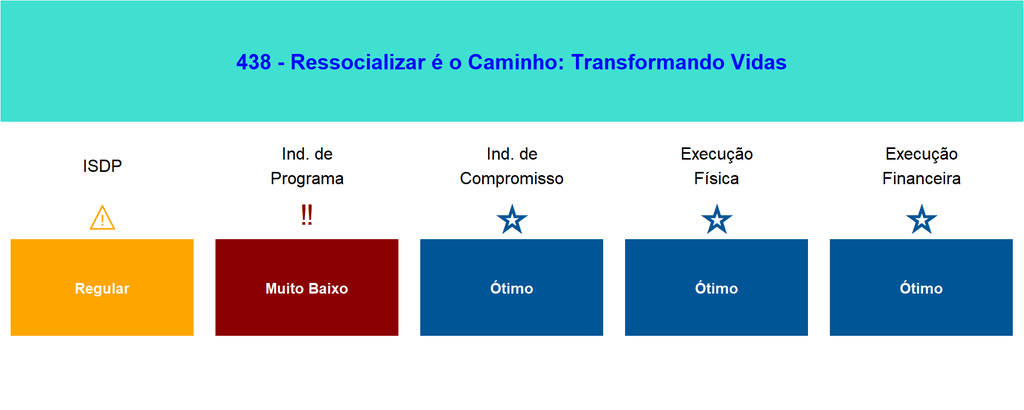

# **2 - Avanços e Conformidades no Programa**

**Indicadores de Programa:** No programa 438 - Ressocializar é o Caminho: Transformando Vidas, não houve evolução positiva em nenhum indicador.  
**Indicadores de Compromisso:** No programa 438 - Ressocializar é o Caminho: Transformando Vidas, 66,6% dos indicadores de compromisso foram avaliados como de bom ou ótimo desempenho. O indicador ‘1 - Proporção de entidades públicas e privadas com termos de cooperação técnica assinados no âmbito da aplicação de alternativas penais’ atingiu 112,09%. Esse desempenho positivo foi fruto dos esforços da CEAPA, que intensificou a articulação interinstitucional e aprimorou os procedimentos administrativos. Também, o indicador ‘2 - Número de núcleos de alternativas penais técnico e estruturalmente adequados’ alcançou 125%, resultado de melhorias na estrutura interna da CEAPA e na organização das unidades prisionais.  
**Ações Orçamentárias:** Para o Programa 438 - Ressocializar é o Caminho: Transformando Vidas, 70% das ações foram classificadas como de bom ou ótimo desempenho financeiro, e 86,4% obtiveram essa classificação na execução física. A Ação 4637 - Assistência ao Interno e Egresso com Oferta de Atividade Laborativa foi avaliada como boa em ambas as frentes, enquanto a Ação 3194 - Aparelhamento de Unidade do Poder Executivo alcançou resultados ótimos.

# **3 - Oportunidade de Melhoria no Programa**

**Indicadores de Programa:** No Programa 438 - “Ressocializar é o Caminho: Transformando Vidas”, todos os indicadores apresentaram evolução negativa. O indicador 2224, referente à taxa de encarceramento em relação à população total, aumentou em 27,51%, alcançando 113,89% em 2025. Esse aumento considera o total de presos da SEAP e SSP em relação à população estimada pelo IBGE, representando um crescimento de 18% em comparação a 2024 (com uma taxa de 96,46%) e de 28% em relação a 2022 (com uma taxa de 89,30%). Este crescimento é resultado de fatores conjunturais, como o aumento da criminalidade e das organizações criminosas, que impactam diretamente a população prisional e os resultados obtidos.  
**Indicadores de Compromisso:** No programa 438 - Ressocializar é o Caminho: Transformando Vidas, não houve indicadores com desempenho baixo ou muito baixo, porém 33,3% foram classificados como de desempenho indeterminado. O indicador ‘2 - Proporção de pessoas privadas de liberdade em atividades educacionais complementares’ obteve um resultado de 232%, superando significativamente a meta anual, graças à ampliação da oferta de atividades culturais e esportivas, especialmente em parceria com a FUNCEB. Outro indicador, ‘5 - Proporção de egressos do sistema penitenciário encaminhados a instituições para acesso a serviços e benefícios socioassistenciais’, alcançou 333,4%. Esse sucesso é resultado da melhoria dos fluxos de identificação e atendimento dos egressos, o que otimizou a execução das ações.  
**Ações Orçamentárias:** No entanto, no Programa 438 - Ressocializar é o Caminho: Transformando Vidas, 20% das ações tiveram desempenho regular na execução financeira, enquanto 9,1% foram classificadas com desempenho baixo ou muito baixo na execução física.

Desenvolvido por: DAP – Diretoria de Avaliação de Políticas Públicas